# Homework 6

Ben Ridenhour

27-Oct-23

#Simulating an SIR model using a Markov Chain

This homework revolved around looking at stochastic dynamics produced by simulating a discrete system of equations using a Markov chain. Recollect that the SIR system is

$$\begin{aligned}
\Delta S &= -\beta S \frac{I}{N} \\
\Delta I &= \beta S \frac{I}{N} - \gamma I \\
(\Delta R &= \gamma I).
\end{aligned}$$
Also, remember that it isn’t necessary to track the changes in the $R$ (recovered) class because it is a closed system, i.e., $N = S + I + R$ is conserved.

# Comparing the Gillespie Algorithm with tau Leaping

The first part of the homework asks you to compare results from the Gillespie algorithm and the tau-leaping algorithm. Parameters for the system are as follows:

1. $N = 500$
2. $\beta = 1/5$
3. $\gamma = 2/15$
4. $S(0) = 499, I(0)=1$.

Finally, the Markov chains should stop once $I = 0$ and 20 replicates of each algorithm should be run. Let’s set up the code to run the two algorithms.

## Writing the Alogorithms

The Gillespie algorithm:

```r
###probMass should return the rate of a particular reaction for a current state of the chain
###there are 2 reactions in this system: infection and recovery
probMass <- function(state, beta = 1/5, gamma = 2/15, N = 500) c(beta*state[1]*state[2]/N, gamma*state[2])

update <- function(theta, ...){
  with(theta,{
  p <- unlist(probMass(state, ...))
  P <- cumsum(c(0,p/sum(p))) #convert to CDF by normalzing
  rand <- runif(1)
  rxn <- max(which(P < rand))
  rxnVec <- rep(0,2)
  rxnVec[rxn] <- 1
  transition <- matrix(c(-1,1,0,-1), nrow = 2)
  #as.vector in the next command is not necessary if you don't care about keeping a labelled vector
  list(state + as.vector(transition %*% rxnVec), "Time" = Time  - log(runif(1))/sum(p))
  })
}


#test the alogrithm
state <- c("S"=499,"I"=1) #initial state
system <- list("state" = state, "Time" = 0)

update(system)
```

```
## [[1]]
##   S   I
## 498   2
##
## $Time
## [1] 5.842148
```

It looks like the Gillespie algorithm worked. Now we define the tau leaping algorithm:

```r
#transProb should return either the net change or the "variance" (squared) change
#for our system the change is given in the orginal equations, again, we have 2 particles/species in
#this system (S,I) that we need to calculate this for
transProb <- function(state, beta = 1/5, gamma = 2/15, N = 500, variance=F) if(!variance) c(-beta*state[1]*state[2]/N,  beta*state[1]*state[2]/N - gamma*state[2]) else c(beta/N*state[1]*state[2],  (beta/N)*state[1]*state[2] + gamma*state[2])


#g is the vector of the highest order of a reaction in the system
#all of our reactions are nonlinear of second order.
update.leaping <- function(theta, pVec, epsilon = 0.03, g = c(2,2), ...){
  with(theta,{
    mu <- transProb(state, ...)
    V <- transProb(state, variance=T, ...)
    L <- sapply(epsilon*state/g, max, 1)
    tau <- min(L/abs(mu), L^2/V)
    ### Now advance the chain
    rxnVec <- rpois(length(g), unlist(probMass(state, ...))*tau)
    transition <- matrix(c(-1,1,0,-1), nrow = 2)
    out <- state + as.vector(transition %*% rxnVec)
    #if we get too large of a step and produce a negative value
    #cut tau in half and try again
    huh <<- out
    while(min(out) < 0){
      tau <- tau/2
      rxnVec <- rpois(length(g), unlist(probMass(state, ...))*tau)
      out <- state + as.vector(transition %*% rxnVec)
    }
    list(out, "Time" = Time  + tau)
  })
}

#test it
update.leaping(system)
```

```
## [[1]]
##   S   I
## 499   0
##
## $Time
## [1] 3.003604
```

It looks like both of the algorithms are working as expected.

## Simulation and Comparison

So the problem asks for 20 iterations of each algorithm. We can handle this using a single for loop. Note that, because the stopping condition for the chain is $I = 0$, we use a `while` loop to iterate the Markov chains.

```r
set.seed(39457)

finalData <- data.frame(Method = NA, Iteration = NA, S = NA, I = NA, Time = NA)
finalData <- finalData[0,]
for(j in 1:20){
  SIR <- data.frame(t(unlist(system)))
  names(SIR) <- c("S","I","Time")
  i <- 1
  while( SIR$I[i] > 0){
    current <- list(state = unlist(SIR[i,1:2]), Time = SIR$Time[i])
    out <- update.leaping(current)
    SIR <- rbind(SIR, data.frame(t(unlist(out))))
    i <- nrow(SIR)
  }

  SIR$Method = "Tau"
  SIR$Iteration = j

  finalData <- rbind(finalData,SIR)

  SIR <- data.frame(t(unlist(system)))
  names(SIR) <- c("S","I","Time")
  i <- 1
  while( SIR$I[i] > 0){
    current <- list(state = unlist(SIR[i,1:2]), Time = SIR$Time[i])
    out <- update(current)
    SIR <- rbind(SIR, data.frame(t(unlist(out))))
    i <- nrow(SIR)
  }

  SIR$Method <- "Gillespie"
  SIR$Iteration <- j

  finalData <- rbind(finalData,SIR)
}
```

How many iterations did it take each algorithm to complete?

Here is the count of the steps each algorithm took to finish:

```r
IterCount <- xtabs(rep(1,nrow(finalData)) ~ Iteration + Method, data = finalData)
IterCount
```

```
##          Method
## Iteration Gillespie Tau
##        1        628 610
##        2         22   7
##        3          2 461
##        4          6   3
##        5          2 592
##        6          2   2
##        7        528 717
##        8        530 727
##        9        496 412
##        10       604   3
##        11         6   2
##        12         4 636
##        13        10   3
##        14         2  13
##        15        66   5
##        16       626 682
##        17       458 552
##        18       402   3
##        19         2   2
##        20       610   5
```

We can also just get the average number of iteration it took per simulation and how often there wasn’t a true epidemic (I set a threshold of 50 iterations):

```r
table(finalData$Method)/20
```

```
##
## Gillespie       Tau
##    250.30    271.85
```

```r
colSums(IterCount > 50)/20
```

```
## Gillespie       Tau
##      0.50      0.45
```

How many people got sick on average?

We can easily tabulate how many people got sick in each simulation. I’ll use the `dplyr` package to do this.

```r
library(dplyr)
finalData %>% group_by(Method,Iteration) %>% filter(S == min(S) & I == 0) -> outbreakSize
outbreakSize$R <- 500 - outbreakSize$S

xtabs(R ~ Iteration + Method, data=outbreakSize)
```

```
##          Method
## Iteration Gillespie Tau
##        1        314 307
##        2         11   3
##        3          1 218
##        4          3   2
##        5          1 297
##        6          1   1
##        7        264 353
##        8        265 362
##        9        248 219
##        10       302   1
##        11         3   1
##        12         2 316
##        13         5   1
##        14         1   7
##        15        33   3
##        16       313 351
##        17       229 297
##        18       201   1
##        19         1   1
##        20       305   4
```

```r
colMeans(xtabs(R ~ Iteration + Method, data=outbreakSize))
```

```
## Gillespie       Tau
##    125.15    137.25
```

```r
outbreaksOnly <- outbreakSize[outbreakSize$R > 50,]
aggregate(outbreaksOnly[,"R",drop=F], outbreaksOnly[,"Method",drop=F], mean)
```

| Method | R |
| --- | --- |
| Gillespie | 271.2222 |
| Tau | 302.2222 |

We can see that with the epidemics that fizzled, the average number of sick people is ~130, while for “full” epidemics it is around 285. We see virtually no difference between the algorithms here again.

How long on average did each outbreak last?

To answer this, we can repeat the previous block of code, this time extracting the value of time at the end of the epidemic.

```r
xtabs(Time ~ Iteration + Method, data=outbreakSize)
```

```
##          Method
## Iteration   Gillespie         Tau
##        1   98.4441254 228.1117550
##        2   21.4200423  18.0433126
##        3    3.3672775  92.3247754
##        4    8.4500338   6.0108216
##        5    0.5586895 128.3076312
##        6    1.9145873   3.0036043
##        7  231.8929398 129.2065073
##        8  130.3629213 157.4872371
##        9  135.1536742 132.8962291
##        10 116.6165153   6.0072087
##        11   7.0491218   3.0036043
##        12  19.3972783 119.1994503
##        13  18.0036698   6.0072087
##        14   2.4965684  16.4733154
##        15  38.7226123  10.5216476
##        16 163.3619648 137.3074912
##        17 128.8264003 137.7233714
##        18 189.0614459   6.0072087
##        19   0.2877730   3.0036043
##        20 114.9179274  12.0397606
```

```r
colMeans(xtabs(Time ~ Iteration + Method, data=outbreakSize))
```

```
## Gillespie       Tau
##  71.51528  67.63429
```

```r
aggregate(outbreaksOnly[,"Time",drop=F], outbreaksOnly[,"Method",drop=F], mean)
```

| Method | Time |
| --- | --- |
| Gillespie | 145.4042 |
| Tau | 140.2849 |

We can see that the algorithms once again agree pretty well. The average number of time steps was around ~70 for all iterations, while for the cases where there were outbreaks the average was around ~140 time steps.

# Characterizing a Stochastic Outbreak

In this portion of the homework, you were asked to simulate to simulate the system a number of times using tau leaping and compare the results. First, let’s do the full simulation of 1000 epidemics.

```r
set.seed(545756)

finalData <- data.frame(Iteration = NA, S = NA, I = NA, Time = NA)
finalData <- finalData[0,]
for(j in 1:1000){
  SIR <- data.frame(t(unlist(system)))
  names(SIR) <- c("S","I","Time")
  i <- 1
  while( SIR$I[i] > 0){
    current <- list(state = unlist(SIR[i,1:2]), Time = SIR$Time[i])
    out <- update.leaping(current)
    SIR <- rbind(SIR, data.frame(t(unlist(out))))
    i <- nrow(SIR)
  }
  SIR$Iteration = j

  finalData <- rbind(finalData,SIR)
}
```

## Plotting the Epidemic Curves

We want to do two things here: 1) plot all the epidemic curves that results from our simulation, and 2) plot the solution of the discrete system as well.

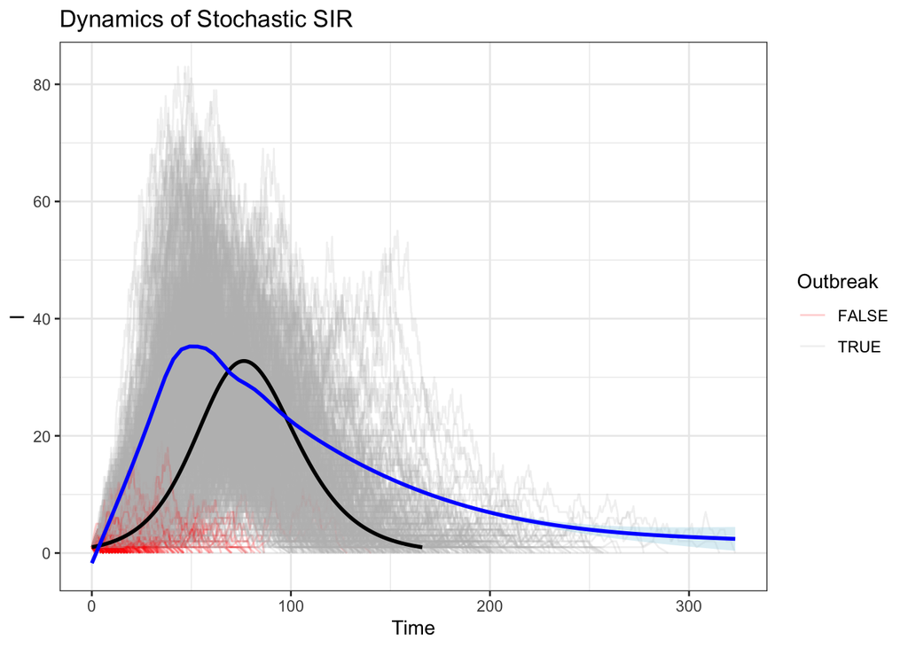

```r
library(ggplot2)
###I want to color the true outbreaks differently
finalData %>% group_by(Iteration) %>% mutate(Outbreak = min(S) < 400)  -> finalData

##Create the discrete solution
discreteSol <- data.frame(S = 499, I = 1, Time = 0)
i <- 1
while(discreteSol$I[i] >= 1){
  newS <- discreteSol$S[i] - 1/5 * discreteSol$S[i] * discreteSol$I[i]/500
  newI <- discreteSol$I[i] + 1/5 * discreteSol$S[i] * discreteSol$I[i]/500 - 2/15 * discreteSol$I[i]
  discreteSol <- rbind(discreteSol, data.frame(S=newS,I=newI,Time = discreteSol$Time[i] + 1))
  i <- nrow(discreteSol)
}
discreteSol$Iteration = 1
discreteSol$Outbreak = T

g <- ggplot(finalData, aes(x=Time, y=I, group = Iteration, color = Outbreak))
g + geom_line(alpha = 0.2) + theme_bw() + scale_color_manual(values = c("red","gray")) + geom_line(data=discreteSol, col="black", lwd =1) + geom_smooth(data = subset(finalData,Outbreak == T), aes(group=NULL), color = "blue", fill="lightblue") + ggtitle("Dynamics of Stochastic SIR")
```

We can see that there is a large amount of variability in this system. Furthermore, the smoothed version of the outbreak dynamics (blue) is considerably different than the deterministic discrete system.

## Summary of the Outbreaks

Next, the problem asks for the mean and variance of the number of sick people, the time to peak epidemic, and duration. Let’s find those quantities:

```r
finalData %>% group_by(Iteration) %>% mutate(Size = max(500 - S - I), Duration = max(Time)) -> finalData
finalData %>% group_by(Iteration) %>% filter(I == max(I)) %>% filter(Time == min(Time)) -> subData

summary(subData[,c("Size","Time","Duration")])
```

```
##       Size            Time           Duration
##  Min.   :  1.0   Min.   :  0.00   Min.   :  1.502
##  1st Qu.:  2.0   1st Qu.:  0.00   1st Qu.:  6.007
##  Median :  8.0   Median : 10.52   Median : 27.880
##  Mean   :123.1   Mean   : 30.80   Mean   : 73.538
##  3rd Qu.:286.0   3rd Qu.: 56.78   3rd Qu.:141.837
##  Max.   :386.0   Max.   :157.55   Max.   :323.214
```

```r
summary(subData[subData$Outbreak,c("Size","Time","Duration")])
```

```
##       Size            Time           Duration
##  Min.   :101.0   Min.   : 15.55   Min.   : 77.84
##  1st Qu.:268.0   1st Qu.: 48.39   1st Qu.:126.58
##  Median :295.0   Median : 61.85   Median :151.53
##  Mean   :287.5   Mean   : 66.62   Mean   :156.56
##  3rd Qu.:318.8   3rd Qu.: 81.58   3rd Qu.:178.04
##  Max.   :386.0   Max.   :157.55   Max.   :323.21
```

Above are the summaries for the final size, time to peak, and duration of the outbreak, respectively. The second set of output is for the case of an outbreak actually happening. When there is actually an outbreak, we can expect the about 287 people to get sick (57.4%), with the max number of infections occurring at $t=66$, and lasting until $t=156$.

## Reducing N to 100

You were asked to reduce N to 100 and simulate the percentage of people who get sick. First run the simulations:

```r
set.seed(548796)

n100 <- data.frame(Iteration = NA, S = NA, I = NA, Time = NA)
n100 <- n100[0,]

system2 <- system
system2$state[1] <- 99

for(j in 1:100){
  SIR <- data.frame(t(unlist(system2)))
  names(SIR) <- c("S","I","Time")
  i <- 1
  while( SIR$I[i] > 0){
    current <- list(state = unlist(SIR[i,1:2]), Time = SIR$Time[i])
    out <- update.leaping(current, N=100)
    SIR <- rbind(SIR, data.frame(t(unlist(out))))
    i <- nrow(SIR)
  }
  SIR$Iteration = j

  n100 <- rbind(n100,SIR)
}
```

Now to find the proportion that got sick:

```r
n100 %>% group_by(Iteration) %>% mutate(Size = max(100 - S - I), Outbreak = Size > 20) %>% filter(Time == max(Time)) -> sub100

summary(sub100[,"Size"])
```

```
##       Size
##  Min.   : 1.00
##  1st Qu.: 2.00
##  Median : 6.50
##  Mean   :28.36
##  3rd Qu.:62.25
##  Max.   :87.00
```

```r
summary(sub100[sub100$Outbreak,"Size"])
```

```
##       Size
##  Min.   :23.00
##  1st Qu.:56.00
##  Median :65.00
##  Mean   :61.91
##  3rd Qu.:74.00
##  Max.   :87.00
```

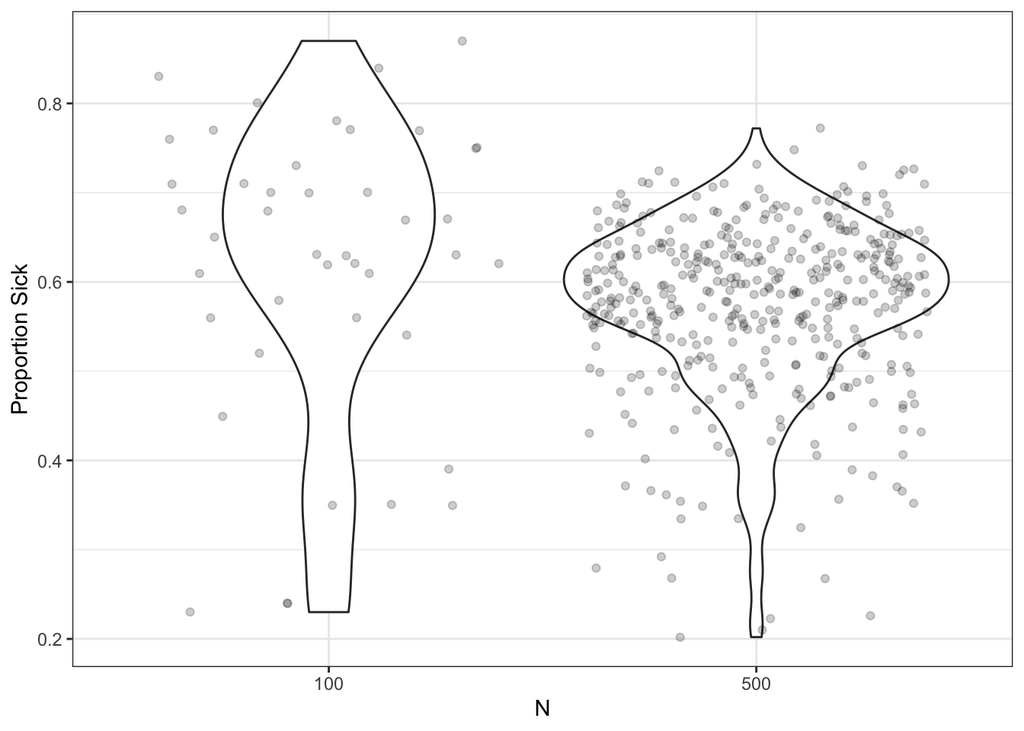

```r
plotIt <- data.frame("N"="100",  sub100[sub100$Outbreak,"Size"]/100)
plotIt <- rbind(plotIt, data.frame("N"="500", subData[subData$Outbreak,"Size"]/500))

g2 <- ggplot(plotIt, aes(x=N, y=Size))
g2 + geom_violin() + theme_bw() + geom_jitter(alpha =0.2) + ylab("Proportion Sick")
```

Looking at the violin plots of the two population sizes we can see that decreasing the population size incresease the variance in the proportion of individuals that get sick.

## Increasing gamma to 2/11

```r
set.seed(234534)

g2_11 <- data.frame(Iteration = NA, S = NA, I = NA, Time = NA)
g2_11 <- g2_11[0,]

for(j in 1:100){
  SIR <- data.frame(t(unlist(system)))
  names(SIR) <- c("S","I","Time")
  i <- 1
  while( SIR$I[i] > 0){
    current <- list(state = unlist(SIR[i,1:2]), Time = SIR$Time[i])
    out <- update.leaping(current, gamma = 2/11)
    SIR <- rbind(SIR, data.frame(t(unlist(out))))
    i <- nrow(SIR)
  }
  SIR$Iteration = j

  g2_11 <- rbind(g2_11,SIR)
}
```

Now find the proportion of the time an outbreak occurred:

```r
g2_11 %>% group_by(Iteration) %>% mutate(Size = max(500 - S - I), Outbreak = Size > 100) %>% filter(Time == max(Time)) -> sub2_11

table(sub2_11$Outbreak)/nrow(sub2_11)
```

```
##
## FALSE  TRUE
##  0.88  0.12
```

```r
table(subData$Outbreak)/nrow(subData)
```

```
##
## FALSE  TRUE
## 0.582 0.418
```

We can see that the proportion of the time an outbreak occurred changed drastically by changing $\gamma = 2/15$ to $\gamma = 2/11$. Why do you think that is?